# Tema 2. Análisis de secuencias

Actualizado en: 27/01/2025

## Objetivos

- ¿Por qué en bioinformática se usa tanto el texto plano?
- ¿Qué consecuencias tiene la diversidad de formatos?
- ¿Qué ventajas y desventajas tienen los archivos binarios?

## Códigos IUPAC. Nucleótidos

| símbolo | significado |
| --- | --- |
| A | Adenine |
| C | Cytosine |
| G | Guanine |
| T (or U) | Thymine (or Uracil) |
| R | A or G |
| Y | C or T |
| S | G or C |
| W | A or T |

| símbolo | significado |
| --- | --- |
| K | G or T |
| M | A or C |
| B | C or G or T |
| D | A or G or T |
| H | A or C or T |
| V | A or C or G |
| N | any base |
| . or - | gap |

## Códigos IUPAC. Aminoácidos

| Símbolo | 3 letras | aminoácido |
| --- | --- | --- |
| A | Ala | Alanine |
| C | Cys | Cysteine |
| D | Asp | Aspartic Acid |
| E | Glu | Glutamic Acid |
| F | Phe | Phenylalanine |
| G | Gly | Glycine |
| H | His | Histidine |
| I | Ile | Isoleucine |
| K | Lys | Lysine |
| L | Leu | Leucine |

| Símbolo | 3 letras | aminoácido |
| --- | --- | --- |
| M | Met | Methionine |
| N | Asn | Asparagine |
| P | Pro | Proline |
| Q | Gln | Glutamine |
| R | Arg | Arginine |
| S | Ser | Serine |
| T | Thr | Threonine |
| V | Val | Valine |
| W | Trp | Tryptophan |
| Y | Tyr | Tyrosine |

## Formatos de texto plano

**Texto plano** es cualquier archivo o conjunto de datos compuesto únicamente por **caracteres**. Se entiende por **caracteres** los símbolos legibles comunes, como letras, números, signos de puntuación, espacios y poco más. Ventaja: la codificación estándard de los caracteres (ASCII, UTF-8, etc) lo hace universal.

Ejemplos de formato plano: FASTA, FASTQ, EMBL, BED, SAM, VCF, GFF, PDB, JSON…

## Formatos binarios

Los archivos en formato **binario** incluyen al menos partes que no pueden ser correctamente interpretadas como caracteres (e.g., números reales). Ventajas: representar cualquier tipo de datos y de forma más eficiente.

Ejemplos: archivos comprimidos, PED binarios (.bed, de plink), BAM, BCF, HDF5…

## Representación de secuencias

- Los ácidos nucleicos se representan siempre de 5’ a 3’.
- Los aminoácidos se representan del extremo N-terminal al C-terminal.
- Casi todos los formatos numeran las bases empezando por 1 (*1-start, fully-closed*):

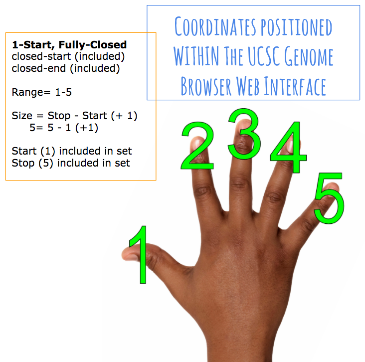

## Representación de secuencias

Las tablas del [navegador genómico de la UCSC](https://genome.ucsc.edu/index.html), en formato BED numeran los nucleótidos de manera diferente, *0-start, half-open*:

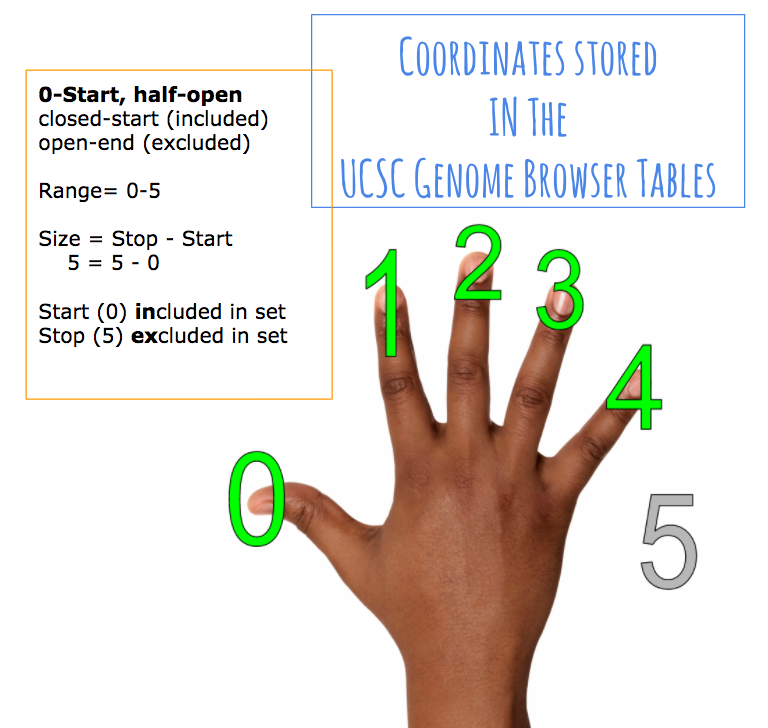

## Formato FASTA

```
>SEQUENCE_1
MTEITAAMVKELRESTGAGMMDCKNALSETNGDFDKAVQLLREKGLGKAAKKADRLAAEG
LVSVKVSDDFTIAAMRPSYLSYEDLDMTFVENEYKALVAELEKENEERRRLKDPNKPEHK
IPQFASRKQLSDAILKEAEEKIKEELKAQGKPEKIWDNIIPGKMNSFIADNSQLDSKLTL
MGQFYVMDDKKTVEQVIAEKEKEFGGKIKIVEFICFEVGEGLEKKTEDFAAEVAAQL
>SEQUENCE_2
SATVSEINSETDFVAKNDQFIALTKDTTAHIQSNSLQSVEELHSSTINGVKFEEYLKSQI
ATIGENLVVRRFATLKAGANGVVNGYIHTNGRVGVVIAAACDSAEVASKSRDLLRQICMH
```

Solo secuencias de un mismo tipo (proteína o ácidos nucleicos) en un archivo.

## Formato FASTQ

```
@SRR001666.1 071112_SLXA-EAS1_s_7:5:1:817:345 length=72
GGGTGATGGCCGCTGCCGATGGCGTCAAATCCCACCAAGTTACCCTTAACAACTTAAGGGTTTTCAAATAGA
+SRR001666.1 071112_SLXA-EAS1_s_7:5:1:817:345 length=72
IIIIIIIIIIIIIIIIIIIIIIIIIIIIII9IG9ICIIIIIIIIIIIIIIIIIIIIDIIIIIII>IIIIII/
@SRR001666.2 071112_SLXA-EAS1_s_7:5:1:801:338 length=72
GTTCAGGGATACGACGTTTGTATTTTAAGAATCTGAAGCAGAAGTCGATGATAATACGCGTCGTTTTATCAT
+SRR001666.2 071112_SLXA-EAS1_s_7:5:1:801:338 length=72
IIIIIIIIIIIIIIIIIIIIIIIIIIIIIIII6IBIIIIIIIIIIIIIIIIIIIIIIIGII>IIIII-I)8I
```

4 líneas por secuencia: `@`nombre, secuencia,`+`(nombre, opcional) y **calidades**.

## Formato FASTQ. Calidades

```
  SSSSSSSSSSSSSSSSSSSSSSSSSSSSSSSSSSSSSSSSS.....................................................
  ..........................XXXXXXXXXXXXXXXXXXXXXXXXXXXXXXXXXXXXXXXXXXXXXX......................
  ...............................IIIIIIIIIIIIIIIIIIIIIIIIIIIIIIIIIIIIIIIII......................
  .................................JJJJJJJJJJJJJJJJJJJJJJJJJJJJJJJJJJJJJJJJ.....................
  LLLLLLLLLLLLLLLLLLLLLLLLLLLLLLLLLLLLLLLLLL....................................................
  PPPPPPPPPPPPPPPPPPPPPPPPPPPPPPPPPPPPPPPPPPPPPPPPPPPPPPPPPPPPPPPPPPPPPPPPPPPPPPPPPPPPPPPPPPPPPP
  !"#$%&'()*+,-./0123456789:;<=>?@ABCDEFGHIJKLMNOPQRSTUVWXYZ[\]^_`abcdefghijklmnopqrstuvwxyz{|}~
  |                         |    |        |                              |                     |
 33                        59   64       73                            104                   126
  0........................26...31.......40
                           -5....0........9.............................40
                                 0........9.............................40
                                    3.....9..............................41
  0.2......................26...31........41
  0..................20........30........40........50..........................................93

 S - Sanger        Phred+33,  raw reads typically (0, 40)
 X - Solexa        Solexa+64, raw reads typically (-5, 40)
 I - Illumina 1.3+ Phred+64,  raw reads typically (0, 40)
 J - Illumina 1.5+ Phred+64,  raw reads typically (3, 41)
     with 0=unused, 1=unused, 2=Read Segment Quality Control Indicator (bold)
 L - Illumina 1.8+ Phred+33,  raw reads typically (0, 41)
 P - PacBio        Phred+33,  HiFi reads typically (0, 93)
```

## Formato FASTQ. Nivel de calidad Phred.

\(Q = -10 \cdot \log_{10}P\)

\(P = 10^{-\frac{Q}{10}}\)

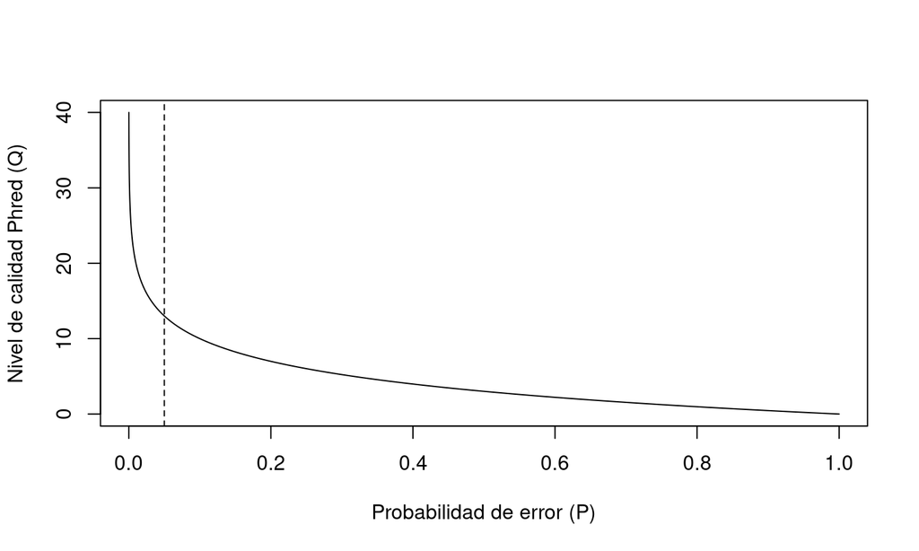

## [Formato EMBL](https://www.ebi.ac.uk/ena/browser/search). Cabecera

```
ID   X64011; SV 1; linear; genomic DNA; STD; PRO; 756 BP.
XX
AC   X64011; S78972;
XX
SV   X64011.1
XX
DT   28-APR-1992 (Rel. 31, Created)
DT   30-JUN-1993 (Rel. 36, Last updated, Version 6)
XX
DE   Listeria ivanovii sod gene for superoxide dismutase
XX
KW   sod gene; superoxide dismutase.
XX
OS   Listeria ivanovii
OC   Bacteria; Firmicutes; Bacillus/Clostridium group;
OC   Bacillus/Staphylococcus group; Listeria.
XX
RN   [1]
RX   MEDLINE; 92140371.
RA   Haas A., Goebel W.;
RT   "Cloning of a superoxide dismutase gene from Listeria ivanovii by
RT   functional complementation in Escherichia coli and characterization of the
RT   gene product.";
RL   Mol. Gen. Genet. 231:313-322(1992).
```

## Formato EMBL. *Features Table*

```
FH   Key             Location/Qualifiers
FH
FT   source          1..756
FT                   /db_xref="taxon:1638"
FT                   /organism="Listeria ivanovii"
FT                   /strain="ATCC 19119"
FT                   /mol_type="genomic DNA"
FT   regulatory      95..100
FT                   /gene="sod"
FT                   /regulatory_class="ribosome_binding_site"
FT   CDS             109..717
FT                   /transl_table=11
FT                   /gene="sod"
FT                   /EC_number="1.15.1.1"
FT                   /db_xref="InterPro:IPR001189"
FT                   /db_xref="UniProtKB/Swiss-Prot:P28763"
FT                   /product="superoxide dismutase"
FT                   /protein_id="CAA45406.1"
FT                   /translation="MTYELPKLPYTYDALEPNFDKETMEIHYTKHHNIYVTKLNEAVSG
FT                   HAELASKPGEELVANLDSVPEEIRGAVRNHGGGHANHTLFWSSLSPNGGGAPTGNLKAA
FT                   IESEFGTFDEFKEKFNAAAAARFGSGWAWLVVNNGKLEIVSTANQDSPLSEGKTPVLGL
FT                   DVWEHAYYLKFQNRRPEYIDTFWNVINWDERNKRFDAAK"
```

## Formato EMBL. Secuencia

```
SQ   Sequence 756 BP; 247 A; 136 C; 151 G; 222 T; 0 other;
     cgttatttaa ggtgttacat agttctatgg aaatagggtc tatacctttc gccttacaat        60
     gtaatttctt ttcacataaa taataaacaa tccgaggagg aatttttaat gacttacgaa       120
     ttaccaaaat taccttatac ttatgatgct ttggagccga attttgataa agaaacaatg       180
     gaaattcact atacaaagca ccacaatatt tatgtaacaa aactaaatga agcagtctca       240
     ggacacgcag aacttgcaag taaacctggg gaagaattag ttgctaatct agatagcgtt       300
     cctgaagaaa ttcgtggcgc agtacgtaac cacggtggtg gacatgctaa ccatacttta       360
     ttctggtcta gtcttagccc aaatggtggt ggtgctccaa ctggtaactt aaaagcagca       420
     atcgaaagcg aattcggcac atttgatgaa ttcaaagaaa aattcaatgc ggcagctgcg       480
     gctcgttttg gttcaggatg ggcatggcta gtagtgaaca atggtaaact agaaattgtt       540
     tccactgcta accaagattc tccacttagc gaaggtaaaa ctccagttct tggcttagat       600
     gtttgggaac atgcttatta tcttaaattc caaaaccgtc gtcctgaata cattgacaca       660
     ttttggaatg taattaactg ggatgaacga aataaacgct ttgacgcagc aaaataatta       720
     tcgaaaggct cacttaggtg ggtcttttta tttcta                                 756
//
```

## Formato GTF/GFF (*General Feature Format*)

```
##gff-version 3.1.26
##sequence-region ctg123 1 1497228
ctg123 . gene            1000 9000  .  +  .  ID=gene00001;Name=EDEN
ctg123 . TF_binding_site 1000 1012  .  +  .  Parent=gene00001
ctg123 . mRNA            1050 9000  .  +  .  ID=mRNA00001;Parent=gene00001
ctg123 . mRNA            1050 9000  .  +  .  ID=mRNA00002;Parent=gene00001
ctg123 . mRNA            1300 9000  .  +  .  ID=mRNA00003;Parent=gene00001
ctg123 . exon            1300 1500  .  +  .  Parent=mRNA00003
ctg123 . exon            1050 1500  .  +  .  Parent=mRNA00001,mRNA00002
ctg123 . exon            3000 3902  .  +  .  Parent=mRNA00001,mRNA00003
ctg123 . exon            5000 5500  .  +  .  Parent=mRNA00001,mRNA00002,mRNA00003
ctg123 . exon            7000 9000  .  +  .  Parent=mRNA00001,mRNA00002,mRNA00003
ctg123 . CDS             1201 1500  .  +  0  ID=cds00001;Parent=mRNA00001
ctg123 . CDS             3000 3902  .  +  0  ID=cds00001;Parent=mRNA00001
ctg123 . CDS             5000 5500  .  +  0  ID=cds00001;Parent=mRNA00001
ctg123 . CDS             7000 7600  .  +  0  ID=cds00001;Parent=mRNA00001
ctg123 . CDS             1201 1500  .  +  0  ID=cds00002;Parent=mRNA00002
ctg123 . CDS             5000 5500  .  +  0  ID=cds00002;Parent=mRNA00002
ctg123 . CDS             7000 7600  .  +  0  ID=cds00002;Parent=mRNA00002
ctg123 . CDS             3301 3902  .  +  0  ID=cds00003;Parent=mRNA00003
ctg123 . CDS             5000 5500  .  +  1  ID=cds00003;Parent=mRNA00003
...
```

## Format GTF/GFF (General Feature Format)

[https://github.com/The-Sequence-Ontology/Specifications/blob/master/gff3.md]

| Columna | Descripción |
| --- | --- |
| 1 | Identificador de secuencia. |
| 2 | Fuente de la anotación. |
| 3 | Tipo. |
| 4-5 | Principio y fin. |
| 6 | Puntuación. |
| 7 | Cadena. |
| 8 | Fase (solo para CDS). |
| 9 | Lista de atributos |

## Formato GTF/GFF

Ejemplo de código de R para leer un archivo GFF3:

```r
# Cargar la libreria:
library('ape')
# Definir la localización del archivo en dos variables "d" y "f":
d <- "https://ftp.ensembl.org/pub/release-86/gff3/homo_sapiens/"
f <- "Homo_sapiens.GRCh38.86.chromosome.MT.gff3.gz"
# Descargar el archivo:
download.file(paste0(d, f), "mt_gff3.gz")
# Leer el archivo a la tabla "gff.mito":
gff.mito <- read.gff("mt_gff3.gz", GFF3 = TRUE)
# Operar sobre "gff.mito", por ejemplo, tabular los tipos:
table(gff.mito$type)
# O extraer los inicios de todos los exones:
gff.mito$start[gff.mito$type == "exon"]
```

## Formato GTF/GFF

```r
library('ape')
d <- "https://ftp.ensembl.org/pub/release-86/gff3/homo_sapiens/"
f <- "Homo_sapiens.GRCh38.86.chromosome.MT.gff3.gz"
download.file(paste0(d, f), "mt_gff3.gz")
gff.mito <- read.gff("mt_gff3.gz", GFF3 = TRUE)
table(gff.mito$type)
```

```
##
## biological_region               CDS        chromosome              exon
##                 1                13                 1                37
##              gene              mRNA           mt_gene        transcript
##                15                13                22                24
```

```r
gff.mito[gff.mito$type == "exon", 'start']
```

```
##  [1]   577   648  1602  1671  3230  3307  4263  4329  4402  4470  5512  5587
## [13]  5657  5761  5826  5904  7446  7518  7586  8295  8366  8527  9207  9991
## [25] 10059 10405 10470 10760 12138 12207 12266 12337 14149 14674 14747 15888
## [37] 15956
```

## Formato BED (*Browser Extensible Data*)

(https://genome.ucsc.edu/FAQ/FAQformat.html#format1)

```
browser position chr7:127471196-127495720
browser hide all
track name="ItemRGBDemo" description="Item RGB demonstration" visibility=2 itemRgb="On"
chr7    127471196  127472363  Pos1  0  +  127471196  127472363  255,0,0
chr7    127472363  127473530  Pos2  0  +  127472363  127473530  255,0,0
chr7    127473530  127474697  Pos3  0  +  127473530  127474697  255,0,0
chr7    127474697  127475864  Pos4  0  +  127474697  127475864  255,0,0
chr7    127475864  127477031  Neg1  0  -  127475864  127477031  0,0,255
chr7    127477031  127478198  Neg2  0  -  127477031  127478198  0,0,255
chr7    127478198  127479365  Neg3  0  -  127478198  127479365  0,0,255
chr7    127479365  127480532  Pos5  0  +  127479365  127480532  255,0,0
chr7    127480532  127481699  Neg4  0  -  127480532  127481699  0,0,255
```

## Bedtools

(https://bedtools.readthedocs.io/en/latest/)

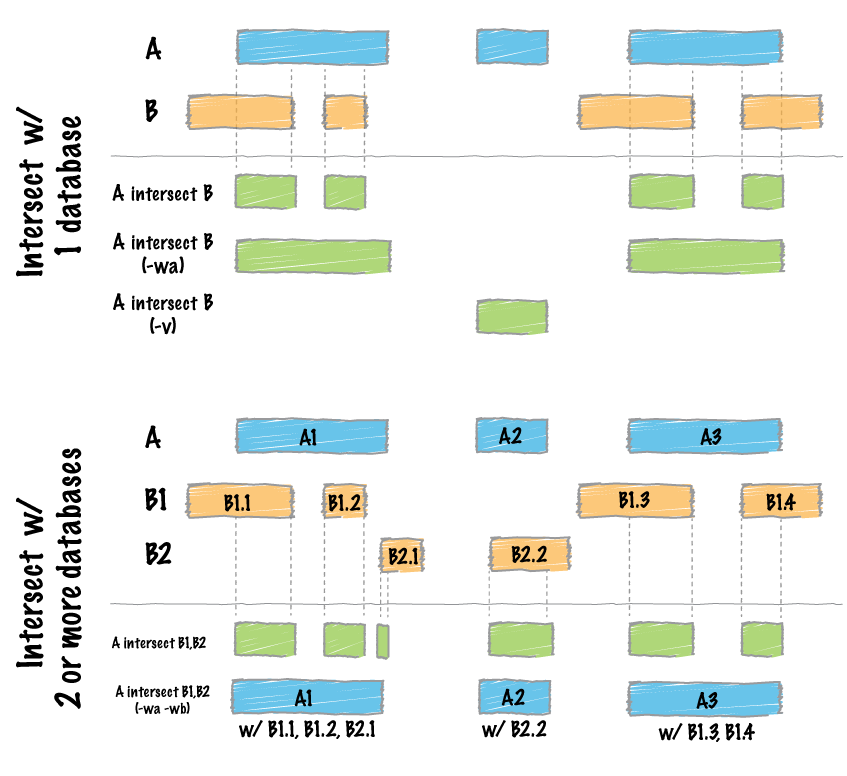

## Formato BED

```r
suppressWarnings(suppressMessages(library('genomation')))
tab.file1 <- system.file("extdata/tab1.bed", package = "genomation")
readGeneric(tab.file1, header = TRUE, keep.all.metadata = TRUE)
```

```
## GRanges object with 6 ranges and 3 metadata columns:
##       seqnames          ranges strand |    cpgNum     gcNum    perCpg
##          <Rle>       <IRanges>  <Rle> | <integer> <integer> <numeric>
##   [1]    chr21 9437272-9439473      * |       285      1426      25.9
##   [2]    chr21 9483485-9484663      * |       165       818      28.0
##   [3]    chr21 9647866-9648116      * |        18       168      14.4
##   [4]    chr21 9708935-9709231      * |        31       218      20.9
##   [5]    chr21 9825442-9826296      * |       120       568      28.1
##   [6]    chr21 9909011-9909218      * |        20       143      19.3
##   -------
##   seqinfo: 1 sequence from an unspecified genome; no seqlengths
```

[genomation](https://www.bioconductor.org/packages/release/bioc/vignettes/genomation/inst/doc/GenomationManual.html)

## Formato SAM. Introducción

```
Coor      12345678901234  5678901234567890123456789012345
ref       AGCATGTTAGATAA**GATAGCTGTGCTAGTAGGCAGTCAGCGCCAT

+r001/1         TTAGATAAAGGATA*CTG
+r002          aaaAGATAA*GGATA
+r003        gcctaAGCTAA
+r004                      ATAGCT..............TCAGC
-r003                             ttagctTAGGC
-r001/2                                         CAGCGGCAT
```

Alineamiento de 6 lecturas cortas a un genoma de referencia. r001/1 i r001/2: lecturas apareadas. Minúsculas: extremos no alineados.

## Formato SAM. Ejemplo

```
@HD VN:1.6 SO:coordinate
@SQ SN:ref LN:45
r001   99 ref  7 30 8M2I4M1D3M  = 37  39 TTAGATAAAGGATACTG *
r002    0 ref  9 30 3S6M1P1I4M  *  0   0 AAAAGATAAGGATA    *
r003    0 ref  9 30 5S6M        *  0   0 GCCTAAGCTAA       * SA:Z:ref,29,-,6H5M,17,0;
r004    0 ref 16 30 6M14N5M     *  0   0 ATAGCTTCAGC       *
r003 2064 ref 29 17 6H5M        *  0   0 TAGGC             * SA:Z:ref,9,+,5S6M,30,1;
r001  147 ref 37 30 9M          =  7 -39 CAGCGGCAT         * NM:i:1
```

La cadena CIGAR **8M2I4M1D3M** describe cómo se alinea la secuencia:

- 8M: 8 nucleótidos alineados (*matched*).
- 2I: 2 nucleótidos insertados.
- 4M: 4 nucleótidos alineados.
- 1D: 1 nucleótido eliminado (*deleted*).
- 3M: 3 nucleótidos alineados.

“S” (*soft clipped*) y “H” (*hard clipped*) indican extremos no alineados.

## Formato SAM. Campos obligatorios

| Columna | Nombre | Tipo | Descripción |
| --- | --- | --- | --- |
| 1 | QNAME | caracteres | Nombre de la secuencia corta |
| 2 | FLAG | número | Marcas binarias |
| 3 | RNAME | caracteres | Nombre de la secuencia de referencia |
| 4 | POS | número | Posición izquierda de mapeo (base 1) |
| 5 | MAPQ | número | Calidad de mapaje (escala Phred) |
| 6 | CIGAR | caracteres | Descripción de alineamiento codificada |
| 7 | RNEXT | caracteres | Referencia donde mapea la pareja (si hay) |
| 8 | PNEXT | número | Posición de la pareja (si hay) |
| 9 | TLEN | número | Longitud observada del fragmento |
| 10 | SEQ | caracteres | Secuencia del segmento |
| 11 | QUAL | caracteres | ASCII de calidades de bases (+33, en Phred) |

## Formato SAM. Marcas binarias

**Hay 10 tipos**

**de personas:**

**las que entienden**

**binario y**

**las que no**

## Formato SAM. Marcas binarias

| Decimal | Binario | Descripción |
| --- | --- | --- |
| 1 | 000000000001 | Lecturas emparejadas. |
| 2 | 000000000010 | Alineamiento concordante. |
| 4 | 000000000100 | Lectura no mapeada. |
| 8 | 000000001000 | Pareja no mapeada. |
| 16 | 000000010000 | SEQ invertida y complementada. |
| 32 | 000000100000 | SEQ de pareja invertida-complementada. |
| 64 | 000001000000 | Primera lectura de la pareja. |
| 128 | 000010000000 | Última lectura de la pareja. |
| 256 | 000100000000 | Alineamiento secundario. |
| 512 | 001000000000 | No pasa los filtros de calidad. |

## Formato VCF

```
##fileformat=VCFv4.0
##fileDate=20110705
##reference=1000GenomesPilot-NCBI37
##phasing=partial
##INFO=<ID=NS,Number=1,Type=Integer,Description="Number of Samples With Data">
##INFO=<ID=DP,Number=1,Type=Integer,Description="Total Depth">
##INFO=<ID=AF,Number=.,Type=Float,Description="Allele Frequency">
##INFO=<ID=AA,Number=1,Type=String,Description="Ancestral Allele">
##INFO=<ID=DB,Number=0,Type=Flag,Description="dbSNP membership, build 129">
##INFO=<ID=H2,Number=0,Type=Flag,Description="HapMap2 membership">
##FILTER=<ID=q10,Description="Quality below 10">
##FILTER=<ID=s50,Description="Less than 50% of samples have data">
##FORMAT=<ID=GQ,Number=1,Type=Integer,Description="Genotype Quality">
##FORMAT=<ID=GT,Number=1,Type=String,Description="Genotype">
##FORMAT=<ID=DP,Number=1,Type=Integer,Description="Read Depth">
##FORMAT=<ID=HQ,Number=2,Type=Integer,Description="Haplotype Quality">
#CHROM POS    ID        REF  ALT     QUAL FILTER INFO                              FORMAT      Sample1        Sample2        Sample3
2      4370   rs6057    G    A       29   .      NS=2;DP=13;AF=0.5;DB;H2           GT:GQ:DP:HQ 0|0:48:1:52,51 1|0:48:8:51,51 1/1:43:5:.,.
2      7330   .         T    A       3    q10    NS=5;DP=12;AF=0.017               GT:GQ:DP:HQ 0|0:46:3:58,50 0|1:3:5:65,3   0/0:41:3
2      110696 rs6055    A    G,T     67   PASS   NS=2;DP=10;AF=0.333,0.667;AA=T;DB GT:GQ:DP:HQ 1|2:21:6:23,27 2|1:2:0:18,2   2/2:35:4
2      130237 .         T    .       47   .      NS=2;DP=16;AA=T                   GT:GQ:DP:HQ 0|0:54:7:56,60 0|0:48:4:56,51 0/0:61:2
2      134567 microsat1 GTCT G,GTACT 50   PASS   NS=2;DP=9;AA=G                    GT:GQ:DP    0/1:35:4       0/2:17:2       1/1:40:3
```

## Formato VCF

[output not shown]

## Formato VCF

[output not shown]

## Formato VCF

[output not shown]

## Formato VCF

[output not shown]

## Formato PDB (*Protein Data Bank*)

```
  HEADER    EXTRACELLULAR MATRIX                    22-JAN-98   1A3I
  TITLE     X-RAY CRYSTALLOGRAPHIC DETERMINATION OF A COLLAGEN-LIKE
  TITLE     2 PEPTIDE WITH THE REPEATING SEQUENCE (PRO-PRO-GLY)
  ...
  EXPDTA    X-RAY DIFFRACTION
  AUTHOR    R.Z.KRAMER,L.VITAGLIANO,J.BELLA,R.BERISIO,L.MAZZARELLA,
  ...
  REMARK 350 BIOMOLECULE: 1
  REMARK 350 APPLY THE FOLLOWING TO CHAINS: A, B, C
  REMARK 350   BIOMT1   1  1.000000  0.000000  0.000000        0.00000
  ...
  SEQRES   1 A    9  PRO PRO GLY PRO PRO GLY PRO PRO GLY
  SEQRES   1 B    6  PRO PRO GLY PRO PRO GLY
  ...
  ATOM      1  N   PRO A   1       8.316  21.206  21.530  1.00 17.44           N
  ATOM      2  CA  PRO A   1       7.608  20.729  20.336  1.00 17.44           C
  ...
  HETATM  130  C   ACY   401       3.682  22.541  11.236  1.00 21.19           C
  HETATM  131  O   ACY   401       2.807  23.097  10.553  1.00 21.19           O
```

## *Hierarchical data format*

[figure not shown]

- Desarrollado por [*The HDF Group*](https://www.hdfgroup.org/).
- Es un formato *abierto*. Actualment en versión 5.
- Almacenaje de muchos datos, de cualquier tipo.
- Metadatos incluidos: el archivo se describe a sí mismo.
- Es binario. Requiere programas específicos.

## Herramientas y ambientes de computación

- Entornos gráficos: [Galaxy](https://usegalaxy.eu/)
- Lenguajes de programación: Python, R, Julia, bash, awk…
- Control de versiones: git
- Gestión de ambientes: conda, pip
- La nube: AWS, etc.